# Dutch trains in 2025: services and performance

Badr El Jaouhari

2026-09-26

## Introduction

NS passengers make more than **one million journeys per day** (Nederlandse Spoorwegen 2026b).

In this presentation, we will take a look at some metrics such as train types, punctuality, seat availability and disruptions. All while using reported figures from the NS Annual Report 2025.

## Sprinter and Intercity

### Sprinter

[figure not shown]

- Stops at almost every intermediate station.
- Serves local and regional journeys.

### Intercity

[figure not shown]

- Stops mainly at larger stations.
- Serves medium and longer journeys.

Source: Nederlandse Spoorwegen (n.d.).

## Connections

A journey involves the departure station, train service and arrival station. Some journeys also require a change of train.

Almost **80% of NS passengers do not need to change trains** (Nederlandse Spoorwegen 2026b). For passengers who do, punctuality affects whether the connection is made.

## Passenger punctuality in 2025

On the main rail network, **85.5%** of passenger journeys arrived within **3 minutes** and **95.3%** within **10 minutes**. The 10-minute figure includes the 3-minute journeys.

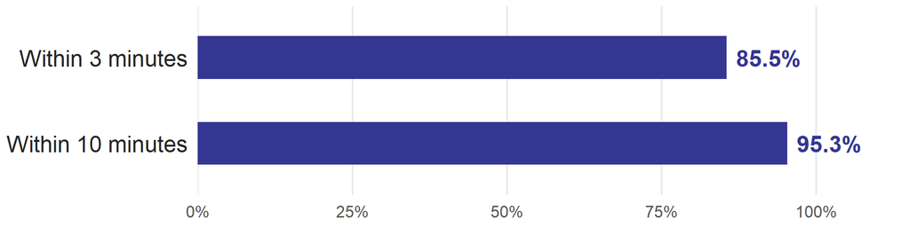

Figure 1

The difference is **9.8 percentage points** (Nederlandse Spoorwegen 2026a).

## Seat availability in 2025

NS estimates the chance that a second-class passenger could sit for the **whole journey** (Nederlandse Spoorwegen 2026a):

- **92.4%** during peak hours
- **98.2%** during off-peak hours

NS reports particularly busy peak periods on Tuesdays and Thursdays (Nederlandse Spoorwegen 2026b).

## Selected performance indicators

The table shows six percentage indicators. Search and sort to compare the 2025 result, annual minimum and 2029 target (Nederlandse Spoorwegen 2026a).

Table 1

| Indicator | Result 2025 | Minimum 2025-29 | Target 2029 |
| --- | --- | --- | --- |
| Punctuality for passengers (with a 3-minute margin) on the main rail network | 85.5 | 84.4 | 86 |
| Punctuality for passengers (with a 10-minute margin) on the main rail network | 95.3 | 94.5 | 95.1 |
| Quality of connections to other carriers | 90.5 | 90.3 | 91.2 |
| Seat availability at peak times in second class | 92.4 | 91.7 | 93.6 |
| Seat availability at off-peak times in second class | 98.2 | 97 | 97.9 |
| Quality of travel information, including disruptions | 72.7 | 70 | 71.8 |

## Difference from the 2029 target

For each indicator, we subtract the 2029 target from the 2025 result:

$$\begin{aligned}
g_j &= \text{result}_{2025,j} - \text{target}_{2029,j} \\
g_{\text{3-minute punctuality}} &= 85.5 - 86.0 = -0.5\ \text{pp} \\
g_{\text{off-peak seats}} &= 98.2 - 97.9 = +0.3\ \text{pp}.
\end{aligned}$$

“pp” means percentage points. A negative value is below the target.

For example, to list the indicators below target in R:

```r
subset(scorecard, `Result 2025` < `Target 2029`)
```

## Interactive comparison

Each dot is the 2025 result minus the 2029 target. (Nederlandse Spoorwegen 2026a).

[interactive chart not shown]

Figure 2

## Disruptions

NS reported **77 high-impact disruptions attributable to it** in 2025 (Nederlandse Spoorwegen 2026a).

A broken-down train can block a track. Following trains then lose time, and some passengers may miss a connection (Nederlandse Spoorwegen 2026b).

NS and ProRail have added minutes at selected locations in the timetable to help trains recover from small delays (Nederlandse Spoorwegen 2026b).

## Which targets were met?

How many of the six indicators had reached their 2029 target in 2025?

```r
sum(scorecard$`Result 2025` >= scorecard$`Target 2029`)
```

```
[1] 3
```

Three of the six results met or exceeded the 2029 target. The indicators measure different aspects of the service.

## References

Nederlandse Spoorwegen. 2026a. “Annual Report 2025: Accessibility Indicators and Targets.” 2026. https://www.nsannualreport.nl/annual-report-2025/sustainability-report/social/accessibility-1.

———. 2026b. “Annual Report 2025: Performance Agreements.” 2026. https://nsannualreport.nl/annual-report-2025/performance-what-we-have-achieved/our-operations/performance-agreements.

———. n.d. “NS Trains in the Netherlands.” https://www.ns.nl/en/travel/trains/in-the-netherlands.